```python
# Hide code cells when saving as HTML
from IPython.display import display
from IPython.display import HTML
import IPython.core.display as di # Example: di.display_html('<h3>%s:</h3>' % str, raw=True)

# This line will hide code by default when the notebook is exported as HTML
di.display_html('<script>jQuery(function() {if (jQuery("body.notebook_app").length == 0) { jQuery(".input_area").toggle(); jQuery(".prompt").toggle();}});</script>', raw=True)

# This line will add a button to toggle visibility of code blocks, for use with the HTML export version
di.display_html('''<button onclick="jQuery('.input_area').toggle(); jQuery('.prompt').toggle();">Toggle code</button>''', raw=True)
```

```python
import pandas as pd
import numpy as np
import seaborn as sns
import matplotlib.pyplot as plt
import matplotlib.dates as dates
import pandas_profiling
import xgboost as xgb

from matplotlib.gridspec import GridSpec
from datetime import datetime, date, time, timedelta
from sklearn.datasets import make_classification
from sklearn.preprocessing import StandardScaler, OneHotEncoder, KBinsDiscretizer, MinMaxScaler, QuantileTransformer
from sklearn.impute import SimpleImputer
from sklearn.compose import ColumnTransformer
from sklearn.ensemble import RandomForestClassifier
from sklearn.tree import DecisionTreeClassifier
from sklearn.model_selection import TimeSeriesSplit #Para split temporal
from sklearn.model_selection import GridSearchCV
#from sklearn.model_selection import train_test_split
from sklearn.metrics import accuracy_score, recall_score, precision_score, f1_score, confusion_matrix, auc, roc_curve
```

```python
# Import created functions (in .py)
import load_data
import clean_data
import transform_data
import eda
import geda
import feature_selection
```

# 1. Introducción

Este proyecto esta enfocado a predecir si una mujer es o no mayor a 23 años dado un conjunto de características presentado en una base de datos.

La base de datos corresponde a las [*Interrupciones Legales de Embarazo*](https://datos.cdmx.gob.mx/explore/dataset/interrupcion-legal-del-embarazo) en la Ciudad de México. Esta base se obtuvo de la página de datos abiertos de la ciudad.

Para contextualizar este proyecto, se consideran los siguientes supuestos:

- El resultado de este proyecto será utilizado por una institución gubernamental, por lo tanto, los recursos son finitos, en particular se tiene un presupuesto limitado.
- Se planea lanzar una campaña de servicios médicos para las mujeres que abortan. Se desea ofrecer servicios a bajo costo o gratuitos de salpingoclasia (esterilización permanente) y se quiere estimular a esta mujeres a participar en otros programas de bienestar social a los que pueden ser elegibles (por ejemplo, de madres solteras)

## 1.1. Interrupción legal del embarazo en la Ciudad de México

Es importante mencionar que la Interrupción del Embarazo solo era legal en la Ciudad de México, hasta hace unas pocas semanas, sin importar la causa o motivo. Pues si bien en otros estados también esta permitido, es sólo bajo ciertas circunstancias, principalmente relacionadas con delitos sexuales.

La interrupción del embarazo es legal en la Ciudad de México hasta las 12 semanas de gestación. Actualmente existen 13 clínicas en la ciudad que otorgan este servicio. La página de información de la CDMX menciona que los servicios se **proporcionan de manera legal, segura, confidencial y gratuita**.

Los requisitos oficiales para obtener el servicio son los siguientes.

Requisitos para residentes de la Ciudad de México

- Identificación oficial, en original y copia.
- Comprobante de domicilio (último recibo de predial, luz, agua, gas, televisión de paga, teléfono fijo o servicio de internet), en original y copia.
- Hoja de Gratuidad. Una trabajadora social te ayudará en caso de no tenerla.
- Un acompañante con identificación oficial en original y copia.
- De manera opcional en los hospitales pueden solicitarte: CURP y/o acta de nacimiento.

Requisitos para menores de edad:

- Acta de Nacimiento en original y copia.
- CURP (Puede imprimirse desde este sitio web)
- Credencial o documento con fotografía reciente (credencial de la escuela o certificado de estudios) en original y copia.
- Comprobante de domicilio en original y copia (último recibo de predial, luz, agua, gas, televisión de paga, teléfono fijo o servicio de internet).
- Acudir acompañada por madre, padre, tutor o representante legal con identificación oficial y comprobante de domicilio, ambos en original y copia.

Requisitos para residentes de otros estados:

- Original y copia de identificación oficial.
- Comprobante de domicilio en original y copia.
- Un acompañante con identificación oficial en original y copia.

# 2. Preprocesamiento de la base

```python
##################################################  LOAD DATASET #############################################################
# Update data file name
datafile_name = 'interrupcion-legal-del-embarazo.csv'

# Update path to data file
path_to_datafile = '~/Documents/Brenda/Proyecto/Data'
#path_to_datafile = '/home/bj/Documents/IntroDataScience/Proyecto/Data'
#path_to_datafile ='C:/Users/GZARAZUA/Desktop/MCD/MINERIA DE DATOS/Reporte aborto'

# Load the dataset
interrupcion_legal = load_data.load_df(datafile_name, path_to_datafile, ';')
```

## 2.1. Descripción de la base

La base contiene información de interrupciones legales de embarazo de 2016 a 2019 Observamos que las variables son en su mayoría numericas (conteos) y algunas categóricas, que se relacionan en lo general con lo siguiente:

- Fecha de registro: ano, mes, fingreso
- Sitio donde se atiende al paciente y datos relacionados a la intervención: cve_hospital, autoref, desc_derechohab, consejería, h_ingreso, desc_servicio, p_consent, procile, s_complica, panticoncept
- Características propias de la persona: edocivil, edad, nivel_edu, ocupacion, religion, parentezco, entidad, alc_o_municipio, menarca, fsexual, fmenstrua, sememb, nhijos, gesta, naborto, npartos, ncesarea, nile, anticonceptivo, c_num, motiles, p_semgest, p_diasgesta

Esta base contiene información acerca de los procedimientos de interrupción legal del embarazo (ILE) que se realizaron en las clínicas y hospitales de la Secretaría de Salud de la Ciudad de México a partir de 2016.

Diccionario de datos:

- ano: Año en que se realizó el procedimiento
- mes: Mes en que se realizó el procedimiento
- cve_hospital: Clave de la Unidad Médica donde se realizó el procedimiento
- fingreso: Fecha de Interrupción Legal del Embarazo
- autoref: Especificar si la paciente es referida de otra unidad o acude directamente
- edocivil_descripcion: Estado civil
- edad: Edad cumplida en años
- desc_derechohab: Especificar la institución que otorga la derechohabiencia
- nivel_edu: Último nivel escola acreditado
- ocupacion: Ocupación
- religion: Religión
- parentesco: Parentesco del responsable con la paciente
- entidad: Entidad de residencia
- alc_o_municipio: Delegación o municipio de residencia
- menarca: Edad de la primera menstruación
- fsexual: Edad de inicio de vida sexual activa
- fmenstrua: Fecha de la última menstruación
- sememb: Semanas de embarazo por fecha de última menstruación
- nhijos: Número de hijos
- gesta: Número de embarazos (Incluyendo abortos)
- naborto: Número de abortos
- npartos: Número de nacimientos por vía vaginal
- ncesarea: Número de cesáreas
- nile: Número de Interrupciones Legales del Embarazo previas
- consejeria: Especificar si la paciente recibió consejería sobre la ILE
- anticonceptivo: Especificar si la paciente utiliza de forma habitual método anticonceptivo
- c_num: Número de consultas
- motiles: Motivo por el cual se desea la interrupción del embarazo
- h_ingreso: En caso de hospitalización, fecha de ingreso
- desc_servicio: Servicio en el que se otorgó la interrupción
- p_semgest: Semanas de gestación por USG
- p_diasgesta: Días de gestación por USG
- p_consent: Se requisitó y firmo el consentimiento informado
- procile: Método utilizado para la interrupción legal
- s_complica: Se presentaron complicaciones por el procedimiento
- panticoncep: Método anticonceptivo proporcionado post evento obstétrico

La variable target es la edad pasada a una variable binaria que indica si es o no mayor de 23 años (>= 23 años). Queremos predecir si dadas las características de la persona que llega a realizarse un aborto es mayor o igual a 23 años o no.

Numericamente se observa que existen datos numericos y categóricos, así como algunas fechas que de inicio no se reconocen porque existen algunos errores que lo impiden

```python
# Define a maximum number of columns to display
pd.options.display.max_columns = 80
# Show raw dataset
#interrupcion_legal.head()
```

```python
####################################### CLEAN NAME VARIABLES ##################################################
# Columns names standardization
clean_interrupcion_legal=clean_data.clean_variables_names(interrupcion_legal)
```

```python
############################################## DATASET GENERAL INFORMATION ##################################################
# General information
#eda.df_variables_info(clean_interrupcion_legal)
# Classify variables per type
[numeric_variables, categorical_variables, dates_variables, string_variables] = eda.info_type_of_vars(clean_interrupcion_legal)
# Print to screen variables per type
#eda.print_info_type_of_vars(numeric_variables, categorical_variables, dates_variables, string_variables)conf_mat.sum(1)
```

```python
#######################################  CLEAN VARIABLES VALUES  #############################################
# Standardization of the values of "string" variables.
# Except fingreso, fmenstrua, h_fingres that are "date" variables, but stored as "string"
clean_interrupcion_legal = transform_data.clean_variables_values(clean_interrupcion_legal, ['mes','autoref','edocivil_descripcion','desc_derechohab','nivel_edu','ocupacion','religion','parentesco','entidad','alc_o_municipio','consejeria','anticonceptivo','motiles','desc_servicio','p_consent','procile','s_complica','panticoncep'
])
```

```python
#######################################  ADJUST TYPES OF VARIABLES ###########################################
# Change type of "fmenstrua" to "date" type

clean_interrupcion_legal['fmenstrua'] = pd.to_datetime(clean_interrupcion_legal['fmenstrua'])
```

```python
# Change type of "fingreso" to "date" type

# Change NA to np.nan
clean_interrupcion_legal['fingreso'] = clean_interrupcion_legal['fingreso'].replace(np.nan,"NA")
# Split fingreso in (year, month, day) and check for errors in dates
dividir = lambda x: pd.Series([i for i in x.split('/')])
aux = clean_interrupcion_legal['fingreso'].apply(dividir)
```

```python
aux = pd.DataFrame(aux)
aux.columns = ['dia','mes','ano']
# Check for months > 12
mes_mayor_12 = aux[pd.to_numeric(aux['mes']) > 12]
#print('Observaciones con mes mayor a 12: \n', mes_mayor_12,'\n')

# Check years before 2016 o greater than 2019 could be errors
ano_menor_16_mayor_19 = aux[(pd.to_numeric(aux['ano'])<16) | (pd.to_numeric(aux['ano'])>19)]
#print('Observaciones con año menor a 2016 o mayor a 2019: \n', ano_menor_16_mayor_19)
```

```python
# Get index with errors
no_observ = mes_mayor_12.loc[mes_mayor_12['mes']=='0719'].index.values[0]
# Set rigth date
clean_interrupcion_legal['fingreso'].iloc[no_observ] = '17/07/19'
```

```python
# Adjut variable 'año' in 'fingreso' according to variable 'ano'
# Differences are assumed as errors
indx = ano_menor_16_mayor_19.index.values
clean_interrupcion_legal.loc[indx, 'fingreso'] = ano_menor_16_mayor_19.iloc[indx, 0] +'/' + ano_menor_16_mayor_19.iloc[indx, 1] + '/' + str(clean_interrupcion_legal.iloc[indx,'ano'])[-2:]
```

```python
#clean_interrupcion_legal[clean_interrupcion_legal['fingreso'].isna()==True]
```

```python
# After correcting errors, we change to "date"
clean_interrupcion_legal['fingreso'] = pd.to_datetime(clean_interrupcion_legal['fingreso'])
```

```python
# Update classification of variables by type
[numeric_variables, categorical_variables, dates_variables, string_variables] = eda.info_type_of_vars(clean_interrupcion_legal)
# eda.print_info_type_of_vars(numeric_variables, categorical_variables, dates_variables, string_variables)
```

## 2.2. Limpieza de datos

Para cada variable se fueron haciendo algunas correcciones de lógica. Para la mayoría de los casos no se cuenta con información sobre el centro de salud o persona que hizo referencia al centro de salud en el que se trata a la paciente. Se corrigen observaciones con 'autorefereida' y 'autorreferida' que se asume como error ortografico.

De aquí en adelante, todas los valores definidos como *N/E*, *no especificado*, ect se definirán con la misma clave **'ne'**.

Notamos que las categorías no son del todo claras, pues existen observaciones donde definen más de un valor como imss/issste o imss/issste/gratuidad.

Se hicieron las siguientes correcciones por variable:

- **Entidad y alc_o_municipio**: En la base original existe un solo registro juan c. bonilla, que debería ser juan c bonilla, no obstante este problema quedó arreglado con la limpieza de los valores de las variables
- **Menarca, fsexual y fmenstrua**: existen valores que parecen no hacer mucho sentido, debido a que son datos con valores numericos (que representan años) muy bajos, pues la primera menstruación y/o relación sexual a los 0,1,2,3,4,5 y 6 años pareciera tratarse de un error. No obstante estas observaciones aparentemente inconsistentes son relativamente mínimas.
- **fmesntrua**: Se observa una fecha fmenstrua mayor a 2019, lo cual se asume como un error y se cambia por NA
- **sememb**: Se considera que el embarazo dura aprox. 40 semanas contadas a partir de la fecha de la última menstruación, sin embargo en la base de datos hay algunos valores mayores a 40 (44,44.5,49,50). Se puede sugerir cambiar los valores mayores a 40 por *nan*.
- **nhijos, gesta, naborto, npartos, ncesarea, nile, consejería**: no se considera que tengan errores y sus valores faltantes son relativamente poco representativos. Cabe señalar que la diferencia entre 'naborto' y 'nile' está en que la primera indica aborto dentro o fuera de la opción legal através de los centros de saludos indicados para ello (pudiese tratarse de un microaborto, aborto clandestino, aborto en otra institución de salud, etc). 'nile' indica no. de abortos en el presente programa
- **h_ingreso**: Existen datos errorneos, pues hay fechas expresadas como entero aparentemente indicando numero de días transcurridos. Existen valores *ne*, para los cuales se debe tener cuidado si se pretende hacer operciones con esta variable.
- **desc_servicio, p_semgest, p_diasgesta, p_consent, procicle, s_complica, panticoncept**: No se encontraron anomalías con los valores de estas variables.

```python
#######################################  CORRECT ORTHOGRAPHIC ERRORS #########################################
# Variable: autoref
# Misspelling 'autorreferida' as 'autorefereida'
clean_interrupcion_legal.loc[clean_interrupcion_legal['autoref']=='autoreferida', 'autoref']='autorreferida'
```

```python
# Variable: desc_derechohab...
clean_interrupcion_legal.loc[clean_interrupcion_legal['edocivil_descripcion']=='n/e', 'edocivil_descripcion']='ne'
```

```python
# Variables: fmenstrua
# values of 'fmenstrua' greater than 2019 are assumed as errors and changed to NaN
clean_interrupcion_legal.loc[clean_interrupcion_legal['fmenstrua'] > pd.Timestamp(date(2019,12,31)), 'fmenstrua']=pd.to_datetime(np.nan)
```

## 2.3. Transformación de datos

Con la finalidad de seguir haciendo hallazgos interesantes en la interacción de las diferentes variables, creamos algunas variables auxiliares, como la que categoriza los valores de 'edad'

```python
####################################### TRASFORMATION OF DATA ################################################
# Create target variable
clean_interrupcion_legal['23_o_mayor'] = np.where(clean_interrupcion_legal['edad'] >= 23, 1, 0)
#clean_interrupcion_legal.head()
```

```python
# Create temporal variable "ano_mes_ile"
mes_num = clean_interrupcion_legal['mes'].map(transform_data.month_string_to_number_string)
clean_interrupcion_legal['ano_mes_ile'] = clean_interrupcion_legal['ano'].astype(str) + "/" + mes_num.astype(str)
# Adjust type to "date"
clean_interrupcion_legal['ano_mes_ile'] = pd.to_datetime(clean_interrupcion_legal['ano_mes_ile'])
```

```python
# Group age by quintils
clean_interrupcion_legal['edad_quintiles'] = pd.cut(clean_interrupcion_legal['edad'], bins=[0,4,9,14,19,24,29,34,39,44,49,54,59,100], labels=["0 a 4", "5 a 9", "10 a 14", "15 a 19", "20 a 24", "25 a 29", "30 a 34", "35 a 39", "40 a 44", "45 a 49", "50 a 54", "55 a 59", "60 y mas"], right=True)
```

```python
# Recategorize civil state  variable 'estado_civil'
dic_edo = {'soltera':'soltera', 'divorciada':'divorciada', 'union_libre':'union_libre', 'casada':'casada',
           'separada':'separada', 'n/e': 'no_especificado', 'na':'no_especificado'}
clean_interrupcion_legal['edo_civil'] = clean_interrupcion_legal['edocivil_descripcion'].map(dic_edo)
```

```python
# Recategorize education level variable ('nivel_educativo')
dic_escol = {'ninguno':'ninguno', 'preescolar':'ninguno', 'primaria_completa':'primaria', 'primaria_incompleta':'primaria',
             'secundaria_incompleta':'secundaria', 'secundaria_completa':'secundaria', 'preparatoria_incompleta':'media_superior',
             'preparatoria_completa':'media_superior', 'carrera_tecnica':'superior', 'licenciatura_incompleta':'superior','licenciatura_completa':'superior',
             'maestria':'posgrado', 'doctorado':'posgrado', 'posgrado':'posgrado', 'posgrado_incompleto':'posgrado',
             'no_especifica':'no_especificado', 'NA':'no_especificado', 'otra':'otra'}

clean_interrupcion_legal['escolaridad'] = clean_interrupcion_legal['nivel_edu'].map(dic_escol)
```

```python
# Recategorize ocupation variable ('ocupacion')
dic_ocup = {'abogada':'profesionista', 'administradora':'profesionista', 'ama_de_casa':'ama_de_casa', 'arquitecta':'profesionista',
            'artista':'profesionista', 'asesora_financiera':'profesionista', 'asesora_juridica':'profesionista', 'auditora':'profesionista',
            'bibliotecaria':'profesionista', 'cajera':'empleada', 'capturista':'empleada', 'chofer':'empleada', 'cientifica':'profesionista',
            'cocinera':'empleada', 'comerciante':'empleada', 'constructora_o_elecetricista':'empleada', 'constructura_o_elecetricista':'empleada',
            'contadora':'empleada', 'dentista':'profesionista', 'desempleada':'desempleada', 'diseñadora':'profesionista',
            'ejecutiva':'profesionista', 'empleada':'empleada', 'enfermera':'profesionista', 'estilista':'empleada',
            'estudiante':'estudiante', 'fisioterapeuta':'empleada', 'fotografa':'empleada', 'informatica_o_tecnologia':'profesionista',
            'ingeniera':'profesionista', 'logistica_o_eventos':'empleada', 'mecanica':'profesionista', 'medico':'profesionista',
            'mesera':'empleada', 'modelo':'empleada', 'na':'no_especificado', 'nutiologa':'profesionista', 'obrera':'empleada',
            'paramedico':'empleada', 'periodista_o_publicista':'profesionista', 'policia_o_seguridad':'empleada',
            'profesora_o_educadora':'profesionista', 'psicologa':'profesionista', 'recepcionista':'empleada', 'recursos_humanos':'empleada',
            'secretaria':'empleada', 'telefonista':'empleada', 'textil':'empleada', 'trabajadora_de_campo':'empleada',
            'trabajadora_del_hogar':'empleada', 'trabajadora_del_sector_publico':'empleada', 'trabajadora_sexual':'trabajadora_sexual',
            'vetarinaria':'profesionista', 'voluntaria_o_trabajadora social':'empleada'}
clean_interrupcion_legal['ocupacion2'] = clean_interrupcion_legal['ocupacion'].map(dic_ocup)
```

```python
# Recategorize use of contraceptive variable ('anticonceptivo')
dic_anti = {'ninguno':'ninguno', 'na':'ninguno','condon':'condon', 'condon_y_otro':'otro',
            'anillo_vaginal':'otro', 'anticoncepcion_de_emergencia':'otro', 'anticoncepcion_de_emergencia_y_otro':'otro',
            'barrera':'otro', 'calendario':'otro', 'coito_interrumpido':'otro', 'diu':'otro', 'hormonal_inyectable':'otro',
            'hormonal_oral':'otro', 'implante_subdermico':'otro', 'inyeccion':'otro', 'medicamento':'otro',
            'parche_dermico':'otro', 'pastillas_anticonceptivas':'otro', 'ritmo':'otro', 'salpingoclacia':'otro',
            'vasectomia':'otro'}
clean_interrupcion_legal['anticonceptivo2'] = clean_interrupcion_legal['anticonceptivo'].map(dic_anti)
```

```python
# Update variables list by type
[numeric_variables, categorical_variables, dates_variables, string_variables] = eda.info_type_of_vars(clean_interrupcion_legal)
#eda.print_info_type_of_vars(numeric_variables, categorical_variables, dates_variables, string_variables)
```

# 3. Data profiling

A continuación se muestra el dataprofiling de nuestras variables resultantes para una fácil identificación de estadísticos (mismos que en forma general ya fueron comentados arriba). Tambien se recomienda consultar el pandas profiling que este código genera

```python
# Data profiling for numeric variables
eda.descriptive_stats_for_numeric_vars(clean_interrupcion_legal, numeric_variables)
```

|  | ano | cve_hospital | edad | menarca | fsexual | sememb | nhijos | gesta | naborto | npartos | ncesarea | nile | c_num | p_semgest | p_diasgesta | 23_o_mayor |
| --- | --- | --- | --- | --- | --- | --- | --- | --- | --- | --- | --- | --- | --- | --- | --- | --- |
| n_observations | 62003 | 62003 | 62003 | 59114 | 57750 | 58403 | 58794 | 59341 | 57888 | 58240 | 57904 | 49598 | 41725 | 61974 | 48602 | 62003 |
| max | 2,019.0 | 14.0 | 53.0 | 30.0 | 54.0 | 50.0 | 10.0 | 47.0 | 10.0 | 12.0 | 7.0 | 9.0 | 26.0 | 12.0 | 94.0 | 1.0 |
| min | 2,016.0 | 1.0 | 11.0 | 1.0 | 0.0 | 0.0 | 0.0 | 0.0 | 0.0 | 0.0 | 0.0 | 0.0 | 0.0 | 0.0 | 0.0 | 0.0 |
| mean | 2,017.2795187329646 | 4.957179491314936 | 25.695450220150637 | 12.640017593125147 | 16.978632034632035 | 7.439771090526172 | 1.0339660509575808 | 2.344921723597513 | 0.17630597014925373 | 0.7116243131868132 | 0.31493506493506496 | 0.17361587160772612 | 1.6839544637507489 | 6.84251460289799 | 5.179334183778446 | 0.6399367772527136 |
| std_dev | 1.0381474298528082 | 3.4456882032173466 | 6.280193269129117 | 1.753794961958415 | 2.4609493406375305 | 2.368693904670961 | 1.1417576189213587 | 1.455346720731206 | 0.47123671673473666 | 1.0662375052601825 | 0.6003706802720097 | 0.4626936383174174 | 0.6848138999004848 | 2.1783800828734057 | 10.42751404607891 | 0.48002230642620536 |
| 25% | 2,016.0 | 2.0 | 21.0 | 12.0 | 15.0 | 6.0 | 0.0 | 1.0 | 0.0 | 0.0 | 0.0 | 0.0 | 1.0 | 5.0 | 2.0 | 0.0 |
| median | 2,017.0 | 4.0 | 24.0 | 12.0 | 17.0 | 7.0 | 1.0 | 2.0 | 0.0 | 0.0 | 0.0 | 0.0 | 2.0 | 7.0 | 3.0 | 1.0 |
| 75% | 2,018.0 | 7.0 | 30.0 | 14.0 | 18.0 | 9.0 | 2.0 | 3.0 | 0.0 | 1.0 | 0.0 | 0.0 | 2.0 | 8.0 | 5.0 | 1.0 |
| kurtosis | -1.1557229957663586 | -0.292966647079814 | 0.01528693535665715 | 1.5144714290155328 | 8.606257442466811 | 19.22649469689396 | 1.829961095309387 | 54.67733886003923 | 27.666905467167425 | 3.005571306591975 | 3.676416830840456 | 18.270847318344636 | 83.16592438014978 | 0.24598576440517927 | 26.49140841800978 | -1.660092699738377 |
| skewness | 0.2082522218434389 | 0.8735922473142439 | 0.7023154398256999 | 0.23398466939627965 | 0.659387999049106 | 1.57747051219976 | 1.1855889643102289 | 3.2655425329343273 | 3.8075528726680195 | 1.6617472122229318 | 1.952495420767913 | 3.400401884645409 | 3.071249544929525 | -0.058139885845661515 | 5.042576695926575 | -0.5830616177459206 |
| n_unique_values | 4 | 14 | 43 | 27 | 44 | 140 | 11 | 26 | 10 | 11 | 7 | 8 | 10 | 13 | 82 | 2 |
| %_missings | 0.0 | 0.0 | 0.0 | 4.659451962001839 | 6.85934551553957 | 5.80617066916117 | 5.175556021482832 | 4.293340644807509 | 6.636775639888393 | 6.0690611744593 | 6.610970436914343 | 20.007096430817864 | 32.70486911923617 | 0.046771930390464976 | 21.613470315952455 | 0.0 |
| Top1_most_common | 2,016.0 | 2.0 | 22.0 | 12.0 | 18.0 | 7.0 | 0.0 | 1.0 | 0.0 | 0.0 | 0.0 | 0.0 | 2.0 | 7.0 | 3.0 | 1.0 |
| Top2_most_common | 2,017.0 | 5.0 | 23.0 | 13.0 | 17.0 | 6.0 | 1.0 | 2.0 | 1.0 | 1.0 | 1.0 | 1.0 | 1.0 | 6.0 | 1.0 | 0.0 |
| Top3_most_common | 2018 | 4 | 21 | 11.0 | 16.0 | 8.0 | 2.0 | 3.0 | 2.0 | 2.0 | 2.0 | 2.0 | 3.0 | 8.0 | 4.0 | - |

La siguiente table indica las estadísticas de la variable categóricas

```python
# Data profiling for categorical variables
eda.descriptive_stats_for_categorical_vars(clean_interrupcion_legal, string_variables)
```

|  | mes | autoref | edocivil_descripcion | desc_derechohab | nivel_edu | ocupacion | religion | parentesco | entidad | alc_o_municipio | consejeria | anticonceptivo | motiles | h_fingreso | desc_servicio | p_consent | procile | s_complica | panticoncep | edo_civil | escolaridad | ocupacion2 | anticonceptivo2 |
| --- | --- | --- | --- | --- | --- | --- | --- | --- | --- | --- | --- | --- | --- | --- | --- | --- | --- | --- | --- | --- | --- | --- | --- |
| n_observations | 62003 | 16874 | 61887 | 54962 | 60719 | 54282 | 60183 | 20163 | 61983 | 57910 | 60047 | 55297 | 60915 | 54466 | 57788 | 17856 | 60290 | 32768 | 45199 | 61707 | 60719 | 54259 | 55297 |
| mode | enero | autorreferida | soltera | ninguna | preparatoria_completa | estudiante | catolica | madre | ciudad_de_mexico | iztapalapa | si | ninguno | interrupcion_voluntaria | NE | ile | si | mifepristona_200_mg_+_misoprostol_800_mcg | no | implante_subdermico | soltera | media_superior | empleada | ninguno |
| num_categories | 12 | 33 | 8 | 35 | 18 | 54 | 14 | 41 | 33 | 498 | 3 | 21 | 14 | 583 | 9 | 3 | 21 | 3 | 45 | 7 | 9 | 7 | 4 |
| categories | [enero, abril, julio, agosto, mayo, febrero, j... | [autorreferida, no, nan, no_especificado, cst_... | [soltera, union_libre, casada, separada, n/e, ... | [ninguna, n/e, gratuidad, imss, otro, seguro_p... | [primaria_completa, licenciatura_completa, sec... | [desempleada, mesera, trabajadora_del_sector_p... | [ninguna, catolica, cristiana, nan, creyente, ... | [amiga, pareja, nan, conyuge, madre, esposo, h... | [estado_de_mexico, ciudad_de_mexico, baja_cali... | [nan, iztapalapa, nezahualcoyotl, coacalco, al... | [si, nan, no] | [anticoncepcion_de_emergencia, condon, diu, ni... | [interrupcion_voluntaria, nan, falta_de_recurs... | [NE, 25/04/16, 24/08/18, 05/07/18, 10/07/18, 0... | [salud_reproductiva, ile, gineco_obstetricia, ... | [si, nan, no] | [misoprostol, aspiracion, mifepristona_200_mg_... | [si, no, nan] | [nan, condon, anticonceptivo_oral, implante_su... | [soltera, union_libre, casada, separada, no_es... | [primaria, superior, secundaria, media_superio... | [desempleada, empleada, ama_de_casa, nan, estu... | [otro, condon, ninguno, nan] |
| n_unique_values | 12 | 32 | 7 | 34 | 17 | 53 | 13 | 40 | 32 | 497 | 2 | 20 | 13 | 582 | 8 | 2 | 20 | 2 | 44 | 6 | 8 | 6 | 3 |
| n_missings | 0 | 45129 | 116 | 7041 | 1284 | 7721 | 1820 | 41840 | 20 | 4093 | 1956 | 6706 | 1088 | 7537 | 4215 | 44147 | 1713 | 29235 | 16804 | 296 | 1284 | 7744 | 6706 |
| %_missings | 0.0 | 72.7851878134929 | 0.1870877215618599 | 11.35590213376772 | 2.0708675386674837 | 12.452623260164831 | 2.9353418382981467 | 67.48060577713981 | 0.03225650371756205 | 6.601293485799074 | 3.1546860635775684 | 10.815605696498556 | 1.7547538022353755 | 12.15586342596326 | 6.798058158476203 | 71.20139348096059 | 2.7627695434091897 | 47.15094430914633 | 27.10191442349564 | 0.47739625501991834 | 2.0708675386674837 | 12.489718239440027 | 10.815605696498556 |
| Top1_most_common | enero | autorreferida | soltera | ninguna | preparatoria_completa | estudiante | catolica | madre | ciudad_de_mexico | iztapalapa | si | ninguno | interrupcion_voluntaria | NE | ile | si | mifepristona_200_mg_+_misoprostol_800_mcg | no | implante_subdermico | soltera | media_superior | empleada | ninguno |
| Top2_most_common | mayo | no | union_libre | gratuidad | secundaria_completa | empleada | ninguna | pareja | estado_de_mexico | gustavo_a_madero | no | condon | no_lo_desea_en_este_momento | 16/01/19 | gineco_obstetricia | no | mifepristona_+_misoprostol | si | diu_medicado | union_libre | secundaria | estudiante | condon |
| Top3_most_common | marzo | no_especificado | casada | imss | licenciatura_completa | ama_de_casa | creyente | esposo | hidalgo | venustiano_carranza | - | diu | falta_de_recursos_economicos | 01/10/18 | consulta_externa | - | misoprostol | - | ne | casada | superior | ama_de_casa | otro |

```python
#clean_interrupcion_legal.head()
```

# 4. EDA

Las variables asociadas al evento posintervención no fueron consideradas para el análsis, pues se considera que no aportan información útil además de que podrían sugerir data leaking

# 5. GEDA

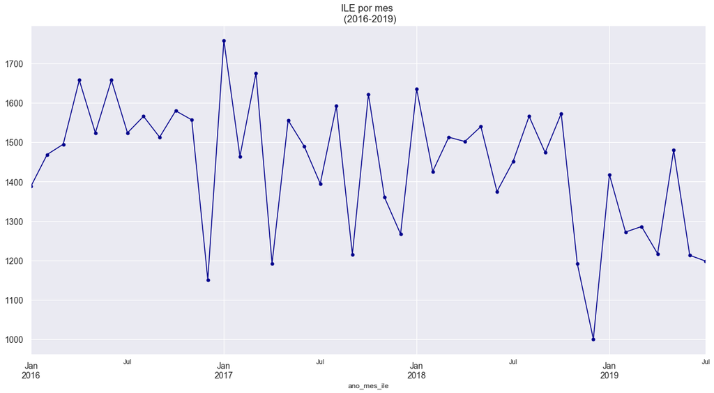

```python
################################################ GRAPHS ######################################################
sns.set_style("darkgrid")
fig, ax = plt.subplots(figsize=(20,10))
clean_interrupcion_legal.groupby(['ano_mes_ile']).count()['ano'].plot(ax=ax,color='darkblue', marker='o')

plt.title('ILE por mes \n (2016-2019)', fontsize='16')
plt.xticks(fontsize='14')
plt.yticks(fontsize='14')
plt.show()
```

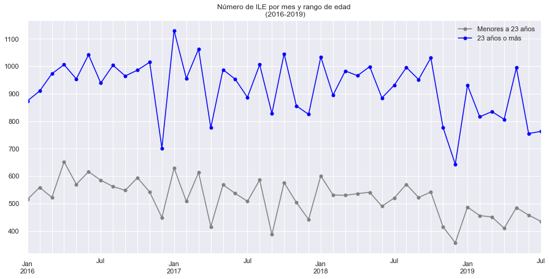

```python
sns.set_style("darkgrid")
fig, ax = plt.subplots(figsize=(15,7))

g = clean_interrupcion_legal.groupby(['ano_mes_ile', '23_o_mayor']).count()['mes'].unstack().plot(ax=ax, marker='o', color= ['gray', 'blue'])

ax.xaxis.grid(True, which='minor')
leg = g.axes.get_legend()
leg.set_title('')
new_labels=['Menores a 23 años', '23 años o más']
for t, l in zip(leg.texts, new_labels): t.set_text(l)

plt.ylabel("")
plt.xlabel("")
plt.title("Número de ILE por mes y rango de edad\n (2016-2019)")
plt.show()
```

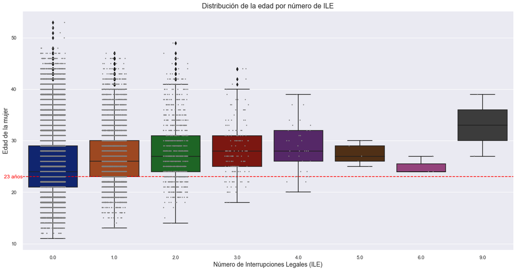

```python
sns.set_style("darkgrid")
plt.figure(figsize = (20,10))
#plt.style.use('ggplot')
plot1 = sns.boxplot(y='edad', x='nile', data=clean_interrupcion_legal, palette='dark')
sns.stripplot(y='edad', x='nile', data=clean_interrupcion_legal, color="gray", jitter=0.2, size=2.5)
# Linea horizontal
plot1.axes.axhline(y = 23, ls='--', color='red')
plot1.axes.text(-0.8, 22.7, "23 años", color = 'red', fontsize=12)

plt.title('Distribución de la edad por número de ILE', fontsize='16')
plt.xlabel('Número de Interrupciones Legales (ILE)', fontsize='14')
plt.ylabel('Edad de la mujer', fontsize='14')

plt.show()
```

En la grafica anterior observamos como se comporta la edad de las mujeres que tuvieron 0,1,2,3,... interrupciones legales de embarazo, observando que apartir de la 3era interrupción las edades de mujeres tienden a concentrarse sólo entre los 20 y 40 años

```python
tabla_pivote = pd.pivot_table(clean_interrupcion_legal, index='edo_civil', columns='23_o_mayor', aggfunc='count')
tabla_pivote = tabla_pivote.reindex(['casada', 'union_libre', 'soltera', 'divorciada', 'separada','no_especificado'])
tabla_pivote['edad']
```

| 23_o_mayor edo_civil | 0 | 1 |
| --- | --- | --- |
| casada | 753 | 5764 |
| union_libre | 5034 | 12680 |
| soltera | 15929 | 18494 |
| divorciada | 149 | 1418 |
| separada | 153 | 763 |
| no_especificado | 245 | 325 |

```python
ile_menor_23 = tabla_pivote['edad'][0]/sum(tabla_pivote['edad'][0])*100
ile_mayor_23 = tabla_pivote['edad'][1]/sum(tabla_pivote['edad'][1])*100
```

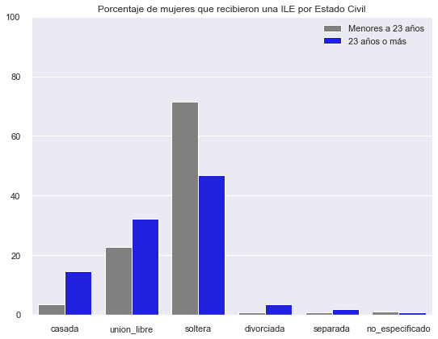

```python
df_aux = pd.DataFrame(tabla_pivote['edad'][0]/sum(tabla_pivote['edad'][0])*100)
df_aux = pd.concat([df_aux, tabla_pivote['edad'][1]/sum(tabla_pivote['edad'][1])*100])
df_aux['23_0_mas'] = [0,0,0,0,0,0,1,1,1,1,1,1]
df_aux['edo_civil1'] = ['casada', 'union_libre', 'soltera', 'divorciada', 'separada','no_especificado', 'casada', 'union_libre', 'soltera', 'divorciada', 'separada','no_especificado']
df_aux.columns = ['Porcentaje', '23_o_mayor', 'edo_civil1']
df_aux.index = df_aux.reset_index(level=0, drop=True)
df_aux.index = [0,1,2,3,4,5,6,7,8,9,10,11]
#
g = sns.catplot(y="Porcentaje", x='edo_civil1', hue='23_o_mayor', kind="bar", data=df_aux, palette=['gray', 'blue'], height=6, aspect=1.3, legend_out=False)
g.ax.set_yticks(np.arange(0,110,10), minor=True)

leg = g.axes.flat[0].get_legend()
leg.set_title('')
new_labels=['Menores a 23 años', '23 años o más']
for t, l in zip(leg.texts, new_labels): t.set_text(l)

plt.ylabel("")
plt.xlabel("")
plt.title("Porcentaje de mujeres que recibieron una ILE por Estado Civil")
plt.show()
```

La gráfica anterior señala que las mujeres más jóvenes que realizan un aborto legal son solteras, lo cual podría asumirse desde un inicio dado el ciclo natural de crecimiento de las personas y una tendencia social a extender la edad de contraer matrimonio

```python
df_aux = clean_interrupcion_legal[clean_interrupcion_legal.edo_civil.isin(['casada', 'soltera','union_libre'])][['edo_civil', 'nile', 'nhijos', '23_o_mayor']]
pd.pivot_table(df_aux, index=['edo_civil', 'nhijos'], columns='nile', aggfunc='count')
#sns.lmplot( y="nile", x="nhijos", data=df_aux, fit_reg=False, hue='edo_civil', legend=True)
```

| edo_civil | nile nhijos | 23_o_mayor 0.0 | 23_o_mayor 1.0 | 23_o_mayor 2.0 | 23_o_mayor 3.0 | 23_o_mayor 4.0 | 23_o_mayor 5.0 | 23_o_mayor 6.0 | 23_o_mayor 9.0 |
| --- | --- | --- | --- | --- | --- | --- | --- | --- | --- |
| casada | 0.0 | 378.0 | 65.0 | 4.0 | nan | nan | nan | nan | nan |
|  | 1.0 | 1,249.0 | 154.0 | 27.0 | 7.0 | nan | 1.0 | nan | nan |
|  | 2.0 | 1,666.0 | 239.0 | 47.0 | 3.0 | 1.0 | 1.0 | nan | nan |
|  | 3.0 | 695.0 | 132.0 | 17.0 | 1.0 | nan | nan | nan | nan |
|  | 4.0 | 184.0 | 33.0 | 7.0 | 1.0 | nan | nan | nan | nan |
|  | 5.0 | 51.0 | 6.0 | nan | nan | 1.0 | nan | nan | nan |
|  | 6.0 | 7.0 | 2.0 | nan | 1.0 | nan | nan | nan | nan |
|  | 7.0 | 2.0 | nan | nan | nan | nan | nan | nan | nan |
|  | 8.0 | 1.0 | nan | nan | nan | nan | nan | nan | nan |
| soltera | 0.0 | 14,405.0 | 1,653.0 | 206.0 | 34.0 | 5.0 | nan | nan | 1.0 |
|  | 1.0 | 5,201.0 | 953.0 | 125.0 | 18.0 | 10.0 | nan | 1.0 | 1.0 |
|  | 2.0 | 2,236.0 | 454.0 | 84.0 | 11.0 | 4.0 | nan | nan | nan |
|  | 3.0 | 653.0 | 140.0 | 42.0 | 7.0 | 3.0 | 1.0 | nan | nan |
|  | 4.0 | 164.0 | 38.0 | 14.0 | 6.0 | 1.0 | nan | nan | nan |
|  | 5.0 | 25.0 | 4.0 | 6.0 | 2.0 | nan | nan | nan | nan |
|  | 6.0 | 21.0 | 8.0 | nan | 1.0 | nan | nan | nan | nan |
|  | 7.0 | 1.0 | 1.0 | nan | nan | nan | nan | nan | nan |
|  | 8.0 | 1.0 | nan | nan | nan | nan | nan | nan | nan |
|  | 10.0 | nan | 1.0 | nan | nan | nan | nan | nan | nan |
| union_libre | 0.0 | 2,568.0 | 324.0 | 36.0 | 9.0 | nan | nan | nan | nan |
|  | 1.0 | 3,877.0 | 549.0 | 69.0 | 11.0 | nan | nan | 1.0 | nan |
|  | 2.0 | 3,329.0 | 583.0 | 83.0 | 14.0 | 1.0 | 1.0 | 1.0 | nan |
|  | 3.0 | 1,279.0 | 238.0 | 42.0 | 5.0 | 1.0 | 1.0 | nan | nan |
|  | 4.0 | 403.0 | 95.0 | 21.0 | 1.0 | nan | nan | nan | nan |
|  | 5.0 | 119.0 | 23.0 | 6.0 | 1.0 | nan | nan | nan | nan |
|  | 6.0 | 37.0 | 11.0 | 4.0 | nan | nan | nan | nan | nan |
|  | 7.0 | 9.0 | 1.0 | nan | nan | nan | nan | nan | nan |
|  | 8.0 | 5.0 | nan | nan | nan | 1.0 | nan | nan | nan |

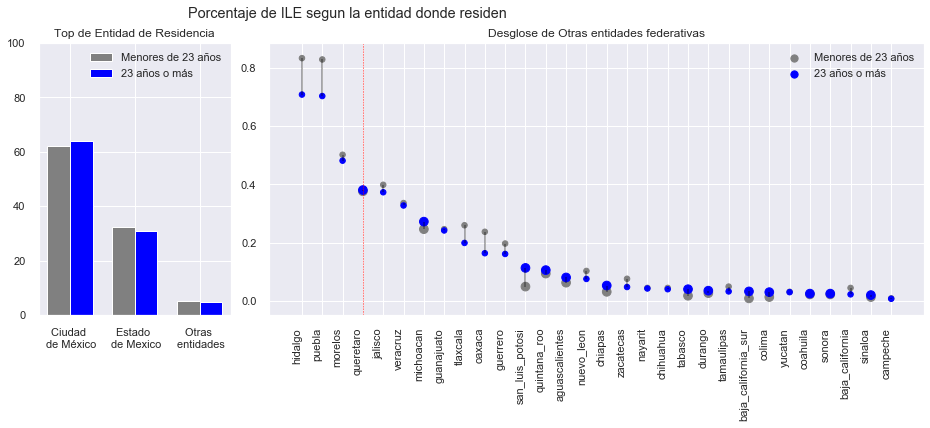

```python
df_aux = clean_interrupcion_legal.groupby(['entidad', '23_o_mayor']).count()['mes'].unstack(level=1).reset_index().sort_values(by=1, ascending=False)
df_aux[0]= df_aux[0]/sum(df_aux[0])*100
df_aux[1]= df_aux[1]/sum(df_aux[1])*100
df_aux.columns = ['entidad', 'menor', 'mayor']

df_aux2 = df_aux[0:2]
df_aux3 = df_aux[2:]
df_aux2 = df_aux2.append(pd.Series(['otras_entidades',sum(df_aux3['menor']), sum(df_aux3['mayor'])], index=df_aux2.columns), ignore_index=True)

#labels = df_aux2['entidad']
labels = ['Ciudad \n de México', 'Estado \n de Mexico', 'Otras \n entidades']
x = np.arange(len(labels))  # the label locations
width = 0.35  # the width of the bars



fig = plt.figure(figsize=(20, 5))
gs = GridSpec(nrows=1, ncols=5)

ax1 = fig.add_subplot(gs[0,1])
ax1.bar(x - width/2, df_aux2['menor'], width, color='gray', label='Menores de 23 años')
ax1.bar(x + width/2, df_aux2['mayor'], width, color='blue', label='23 años o más')
ax1.set_xticks(x)
ax1.set_xticklabels(labels)
ax1.set_yticks(np.arange(0,110,10), minor=True)
ax1.set_title("Top de Entidad de Residencia")
ax1.legend(loc='upper right')

ax2 = fig.add_subplot(gs[0,2:])
my_size=np.where(df_aux3['mayor']>df_aux3['menor'], 75, 30)
my_range = df_aux3['entidad']
ax2.vlines(x = my_range, ymin=df_aux3['menor'], ymax=df_aux3['mayor'], color='black', alpha=0.4)
ax2.axvline(x = 'queretaro', color='red', ls='--', linewidth=0.5)
ax2.scatter(my_range, df_aux3['menor'], color='gray', s=my_size, alpha=1, label='Menores de 23 años')
ax2.scatter(my_range, df_aux3['mayor'], color='blue', s=my_size, alpha=1 , label='23 años o más')
ax2.set_xticks(np.arange(len(my_range)))
ax2.set_xticklabels(my_range, rotation=90, horizontalalignment='right')
ax2.set_title("Desglose de Otras entidades federativas")
ax2.legend(loc='upper right')

fig.suptitle("Porcentaje de ILE segun la entidad donde residen")
#format_axes(fig)

plt.show()
```

```python
pd.options.display.float_format = '{:,}'.format
pivot_aux = pd.pivot_table(clean_interrupcion_legal, index='escolaridad', columns='edo_civil', aggfunc='count')['mes']
pivot_aux = pivot_aux.reindex(['posgrado', 'superior', 'media_superior', 'secundaria', 'primaria','otra', 'ninguno', 'no_especificado' ])
pivot_aux = pivot_aux[['casada', 'union_libre', 'soltera', 'divorciada', 'separada','no_especificado']]
pivot_aux
#sns.heatmap(pivot_aux)
#pd.pivot_table(clean_interrupcion_legal, index='escolaridad', columns=['23_o_mayor', 'edo_civil'], aggfunc='count')['mes']
```

| edo_civil escolaridad | casada | union_libre | soltera | divorciada | separada | no_especificado |
| --- | --- | --- | --- | --- | --- | --- |
| posgrado | 34.0 | 47.0 | 155.0 | 10.0 | 1.0 | nan |
| superior | 1,012.0 | 2,092.0 | 6,992.0 | 216.0 | 27.0 | 53.0 |
| media_superior | 2,854.0 | 7,463.0 | 16,631.0 | 630.0 | 325.0 | 155.0 |
| secundaria | 2,051.0 | 6,347.0 | 8,307.0 | 595.0 | 442.0 | 109.0 |
| primaria | 345.0 | 1,229.0 | 1,156.0 | 85.0 | 72.0 | 17.0 |
| otra | 11.0 | 52.0 | 41.0 | nan | 9.0 | nan |
| ninguno | 62.0 | 185.0 | 264.0 | 13.0 | 5.0 | 52.0 |
| no_especificado | 12.0 | 34.0 | 49.0 | 1.0 | 4.0 | 179.0 |

De esta muestra que la mayoría de las mujeres comparte la característica de estar soltera y tener como grado máximo de estudios educación media superior o secundaria. La mayoría de las mujeres que viven en unión libre comparte el mismo nivel máximo de estudios indicado anterioremente

```python
clean_interrupcion_legal[clean_interrupcion_legal['escolaridad']=='no_especificado']
```

|  | ano | mes | cve_hospital | fingreso | autoref | edocivil_descripcion | edad | desc_derechohab | nivel_edu | ocupacion | religion | parentesco | entidad | alc_o_municipio | menarca | fsexual | fmenstrua | sememb | nhijos | gesta | naborto | npartos | ncesarea | nile | consejeria | anticonceptivo | c_num | motiles | h_fingreso | … |
| --- | --- | --- | --- | --- | --- | --- | --- | --- | --- | --- | --- | --- | --- | --- | --- | --- | --- | --- | --- | --- | --- | --- | --- | --- | --- | --- | --- | --- | --- | --- |
| 81 | 2018 | octubre | 13 | NaT | no | n/e | 27 | gratuidad | no_especifica | NaN | ninguna | esposo | ciudad_de_mexico | tlalpan | 16.0 | 27.0 | NaT | 0.0 | 0.0 | 2.0 | 1.0 | nan | nan | 1.0 | si | ninguno | 1.0 | interrupcion_voluntaria | 30/10/18 | … |
| 245 | 2016 | septiembre | 7 | 2016-09-20 | no | n/e | 24 | ninguna | no_especifica | NaN | catolica | otro_u_otra | ciudad_de_mexico | alvaro_obregon | 11.0 | 17.0 | 2016-07-15 | 10.0 | 2.0 | 1.0 | 0.0 | 1.0 | 0.0 | 0.0 | si | diu | 2.0 | interrupcion_voluntaria | NE | … |
| 412 | 2016 | mayo | 7 | 2016-05-19 | no | n/e | 21 | ninguna | no_especifica | NaN | catolica | otro_u_otra | ciudad_de_mexico | alvaro_obregon | 9.0 | 13.0 | 2016-03-15 | 10.0 | 4.0 | 3.0 | 0.0 | 3.0 | 0.0 | 0.0 | si | ninguno | 2.0 | interrupcion_voluntaria | NE | … |
| 417 | 2017 | agosto | 13 | 2017-08-29 | autorreferida | n/e | 20 | n/e | no_especifica | desempleada | ninguna | madre | ciudad_de_mexico | iztapalapa | 12.0 | nan | 2017-03-06 | 11.1 | 1.0 | 2.0 | 0.0 | 0.0 | 0.0 | 0.0 | si | ninguno | nan | interrupcion_voluntaria | NE | … |
| 420 | 2017 | septiembre | 13 | 2017-09-15 | autorreferida | n/e | 23 | n/e | no_especifica | NaN | ninguna | madre | ciudad_de_mexico | xochimilco | 13.0 | nan | 2017-02-08 | 7.0 | 0.0 | 2.0 | 0.0 | 0.0 | 1.0 | 0.0 | si | ninguno | nan | interrupcion_voluntaria | NE | … |
| ... | ... | ... | ... | ... | ... | ... | ... | ... | ... | ... | ... | ... | ... | ... | ... | ... | ... | ... | ... | ... | ... | ... | ... | ... | ... | ... | ... | ... | ... | … |
| 60392 | 2019 | abril | 8 | 2019-08-04 | NaN | soltera | 40 | NaN | no_especifica | NaN | ninguna | amiga | estado_de_mexico | ecatepec_de_morelos | 14.0 | 17.0 | NaT | 8.0 | 4.0 | 5.0 | 0.0 | 4.0 | 0.0 | 0.0 | NaN | condon | 1.0 | interrupcion_voluntaria | 08/04/19 | … |
| 60728 | 2019 | mayo | 11 | 2019-03-05 | NaN | soltera | 19 | gratuidad | no_especifica | empleada | catolica | amiga | ciudad_de_mexico | cuauhtemoc | 12.0 | 16.0 | NaT | 12.0 | nan | 1.0 | 0.0 | 0.0 | 0.0 | 0.0 | NaN | ninguno | 1.0 | interrupcion_voluntaria | 03/05/19 | … |
| 60753 | 2019 | mayo | 7 | 2019-09-05 | NaN | NaN | 27 | NaN | no_especifica | NaN | ninguna | otra_u_otro | ciudad_de_mexico | alvaro_obregon | 14.0 | 16.0 | NaT | 6.0 | 0.0 | 1.0 | 0.0 | 0.0 | 0.0 | 0.0 | si | condon | 2.0 | interrupcion_voluntaria | 09/05/19 | … |
| 60767 | 2019 | mayo | 7 | 2019-05-23 | NaN | union_libre | 27 | seguro_popular | no_especifica | NaN | ninguna | NaN | ciudad_de_mexico | NaN | 15.0 | 19.0 | NaT | 5.0 | 1.0 | 2.0 | 0.0 | 1.0 | 0.0 | 0.0 | si | condon | 2.0 | interrupcion_voluntaria | 23/05/19 | … |
| 61692 | 2019 | julio | 10 | 2019-02-07 | NaN | soltera | 20 | gratuidad | no_especifica | NaN | ninguna | concubino | ciudad_de_mexico | azcapotzalco | 12.0 | 16.0 | NaT | 10.4 | 0.0 | 1.0 | nan | nan | nan | 0.0 | NaN | anticoncepcion_de_emergencia | 1.0 | interrupcion_voluntaria | 02/07/19 | … |

342 rows × 43 columns

```python
pivot_aux = pd.pivot_table(clean_interrupcion_legal, index='escolaridad', columns='ocupacion2', aggfunc='count')['mes']
pivot_aux = pivot_aux.reindex(['posgrado', 'superior', 'media_superior', 'secundaria', 'primaria','otra', 'ninguno', 'no_especificado' ])
pivot_aux
```

| ocupacion2 escolaridad | ama_de_casa | desempleada | empleada | estudiante | profesionista | trabajadora_sexual |
| --- | --- | --- | --- | --- | --- | --- |
| posgrado | 5.0 | 18.0 | 150.0 | 57.0 | 12.0 | nan |
| superior | 535.0 | 709.0 | 4,356.0 | 3,893.0 | 225.0 | nan |
| media_superior | 3,962.0 | 1,420.0 | 10,904.0 | 8,870.0 | 85.0 | 4.0 |
| secundaria | 4,505.0 | 889.0 | 7,375.0 | 2,103.0 | 24.0 | 2.0 |
| primaria | 841.0 | 108.0 | 1,220.0 | 138.0 | nan | nan |
| otra | 66.0 | nan | 35.0 | 12.0 | nan | nan |
| ninguno | 100.0 | 23.0 | 209.0 | 84.0 | 2.0 | nan |
| no_especificado | 27.0 | 5.0 | 15.0 | 11.0 | nan | nan |

Esta otra tabla muestra que la mayoría de mujeres tiene el nivel máximo de estudios de secundaria o media superior, y que existe un grupo considerable de mujeres que depende monetariamente de terceros, pues el grupo de estudiantes y amas de casa es significativo. La mayoría de mujeres se caracteriza por ser empleadas.

```python
pivot_aux = pd.pivot_table(clean_interrupcion_legal, index='edo_civil', columns='ocupacion2', aggfunc='count')['mes']
pivot_aux = pivot_aux.reindex(['casada', 'union_libre', 'soltera', 'divorciada', 'separada','no_especificado'])
pivot_aux
```

| ocupacion2 edo_civil | ama_de_casa | desempleada | empleada | estudiante | profesionista | trabajadora_sexual |
| --- | --- | --- | --- | --- | --- | --- |
| casada | 2,179.0 | 147.0 | 2,191.0 | 424.0 | 48.0 | 1.0 |
| union_libre | 5,167.0 | 638.0 | 6,184.0 | 2,073.0 | 67.0 | 1.0 |
| soltera | 2,506.0 | 2,163.0 | 14,491.0 | 12,942.0 | 228.0 | 4.0 |
| divorciada | 124.0 | 173.0 | 1,036.0 | 68.0 | 7.0 | nan |
| separada | 193.0 | 82.0 | 556.0 | 52.0 | 1.0 | nan |
| no_especificado | 26.0 | 21.0 | 135.0 | 112.0 | 3.0 | nan |

```python
####################################  PANDAS PROFILING  #########################################
# #Imprime a pantalla
# clean_interrupcion_legal.profile_report(correlations={"cramers": False})

# #Imprime a archivo

# profile = clean_interrupcion_legal.profile_report(title='Interrupcion legal del embarazo', plot={'histogram': {'bins': 8}}, correlations={"cramers": False})
# profile.to_file(output_file="Interrupcion legal del embarazo_output.html")
```

```python
# #guardamos la base de datos resultante a un .csv
# clean_interrupcion_legal.to_csv('clean_interrupcion_legal.csv', sep=';')
```

```python
#geda.boxplot_all(clean_interrupcion_legal, numeric_variables)
```

La mayoría de las mujeres son empleadas/estudiantes y solteras, aunque existen otros grupos significativos como las mujeres que se dicen vivir en unión libre, que en su mayoría son amas de casa o empleadas.

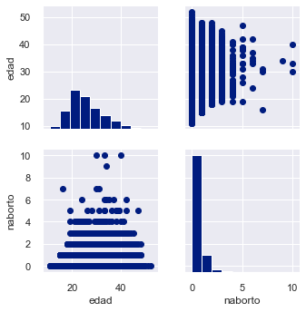

```python
sns.set_style("darkgrid")
sns.set_palette("dark")
geda.plot_by_pairs_grid(clean_interrupcion_legal, ['edad','naborto'])
```

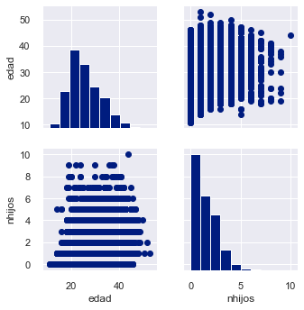

```python
geda.plot_by_pairs_grid(clean_interrupcion_legal, ['edad','nhijos'])
```

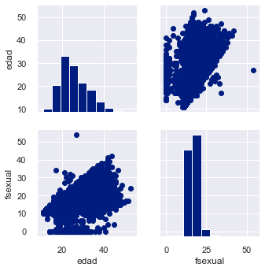

```python
geda.plot_by_pairs_grid(clean_interrupcion_legal, ['edad','fsexual'])
```

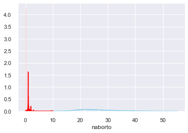

```python
geda.plot_bivariate_hist(clean_interrupcion_legal, 'edad', 'naborto')
```

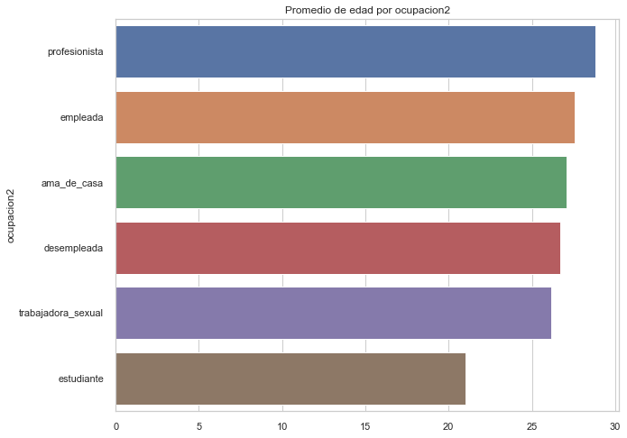

```python
geda.barplot_by_category(clean_interrupcion_legal, 'edad', 'ocupacion2')
```

Una suposición natural indica que que la mayoría de mujeres estudiantes son jóvenes, lo cual se corrobora con la gráfica anterior. El resto de ocupaciones indican una poblacion que supera los 23 años, lo que podría ser un indicativo en la importancia de esta variables en la predicción de la edad

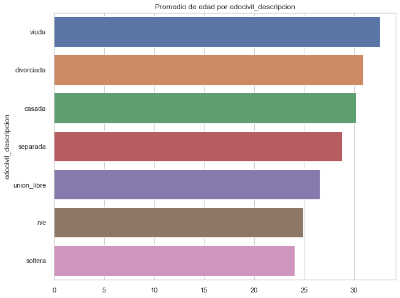

```python
geda.barplot_by_category(clean_interrupcion_legal, 'edad', 'edocivil_descripcion')
```

Pareciera existir una relacion entre el edo civil y la edad de las mujeres que practican interrupción del embarazo, pues el promedio de edad es diferente para cada categoría. No obstante lo anterior, se tendría que analizar más a fondo la distribución de los datos, pues la medida de promedio es muy sensible a outlayers

# Insights más importantes de este conjunto de datos

# 6. Selección de variables

Algunas variables categoricas se recategorizaron para agrupar etiquetas similares y disminuir el número de categorias.

Originalmente se tienen 36 variables, y aunque no es un gran número de variables en términos de los modelos de aprendizaje de máquina, es importante hacer la selección de variables para eliminar aquellas ue son espurias y que pudieran estar incorporando ruido al modelo y por lo tanto, disminuir su desempeño.

En base al EDA se incluyeron 10 variables (edo_civil, escolaridad, ocupacion2, menarca, anticonceptivo2, nhijos, naborto, npartos, ncesarea, nile) para correr un modelo de Random Forest para determinar el nivel de importancia de las variables.

Referencia [aqui](https://www.datacamp.com/community/tutorials/random-forests-classifier-python)

## 6.1. Separacion de datos de *entrenamiento* y *prueba*

La partición de la base en el conjunto de entrenamiento y de prueba, se realizo usando **temporal cross validation**, pues los eventos considerados (ILE) están intrínsicamente relacionados con el tiempo. Además, las características de la observaciones en la base, y de la población objetivo -mujeres de 23 años o más- en particular, son cambiantes a lo largo del tiempo.

La muestra de entrenamiento se selecciono desde la fecha más antigua del primer registro (2016-01-01) hasta la fecha límite elegida, en este caso 2018-07-01. Así, la muestra de prueba fueron las observaciones a partir de 2018-08-01 y hasta la última fecha disponible en la base (2019-07-01).

Esta fecha se eligio para tener al menos un año en la muestra de prueba, pensando que puede haber estacionalidad a lo largo de un año. Además, con esta fecha se obtiene que el 74% de los datos se encuentran en la muestra de entrenamiento y el restante en la muestra de prueba.

```python
#######################################  SELECTION OF VARIABLES  #############################################
base_interrupcion_legal = clean_interrupcion_legal[['ano_mes_ile', '23_o_mayor', 'edo_civil', 'escolaridad', 'ocupacion2', 'menarca', 'anticonceptivo2', 'nhijos', 'naborto', 'npartos', 'ncesarea', 'nile' ]].copy()

# Order dataset by the temporal variable 'ano_mes_ile'
base_interrupcion_legal.sort_values(by=['ano_mes_ile'], ascending=True)

#base_interrupcion_legal
```

|  | ano_mes_ile | 23_o_mayor | edo_civil | escolaridad | ocupacion2 | menarca | anticonceptivo2 | nhijos | naborto | npartos | ncesarea | nile |
| --- | --- | --- | --- | --- | --- | --- | --- | --- | --- | --- | --- | --- |
| 0 | 2016-01-01 | 1 | soltera | primaria | desempleada | 11.0 | otro | 1.0 | 0.0 | 0.0 | 1.0 | 1.0 |
| 20672 | 2016-01-01 | 1 | union_libre | primaria | NaN | 15.0 | otro | 4.0 | 0.0 | 4.0 | 0.0 | 0.0 |
| 20674 | 2016-01-01 | 1 | soltera | secundaria | empleada | 14.0 | ninguno | 2.0 | nan | nan | 2.0 | 0.0 |
| 12203 | 2016-01-01 | 0 | soltera | media_superior | estudiante | 11.0 | ninguno | 0.0 | 0.0 | 0.0 | 0.0 | nan |
| 20763 | 2016-01-01 | 1 | casada | secundaria | empleada | 13.0 | otro | 1.0 | 0.0 | 0.0 | 1.0 | nan |
| ... | ... | ... | ... | ... | ... | ... | ... | ... | ... | ... | ... | ... |
| 58763 | 2019-07-01 | 0 | soltera | media_superior | estudiante | 12.0 | condon | 0.0 | 0.0 | 0.0 | 0.0 | 0.0 |
| 58762 | 2019-07-01 | 1 | NaN | secundaria | empleada | 14.0 | ninguno | 4.0 | 0.0 | 4.0 | 0.0 | 0.0 |
| 58761 | 2019-07-01 | 1 | soltera | secundaria | empleada | 14.0 | NaN | 2.0 | 0.0 | 2.0 | 0.0 | 0.0 |
| 58759 | 2019-07-01 | 1 | union_libre | media_superior | estudiante | 14.0 | ninguno | 1.0 | 1.0 | 0.0 | 1.0 | 0.0 |
| 62002 | 2019-07-01 | 1 | divorciada | media_superior | ama_de_casa | 12.0 | ninguno | 4.0 | 0.0 | 4.0 | 0.0 | 0.0 |

62003 rows × 12 columns

```python
##################################### SPLIT IN 'test' AND 'train' ###############################
FECHA_DE_CORTE = '2018-07-01'
mask = (base_interrupcion_legal['ano_mes_ile'] <= FECHA_DE_CORTE)
entrenamiento = base_interrupcion_legal[mask]
prueba = base_interrupcion_legal[~mask]
print('No. observaciones en entre: ', entrenamiento.shape[0], ' que representa el ', round(entrenamiento.shape[0]/base_interrupcion_legal.shape[0]*100,0),'%')
print('No. observaciones en prueb: ', prueba.shape[0], ' que representa el ', round(prueba.shape[0]/base_interrupcion_legal.shape[0]*100,0),'%')
```

```
No. observaciones en entre:  46114  que representa el  74.0 %
No. observaciones en prueb:  15889  que representa el  26.0 %
```

```python
y_entrenamiento = entrenamiento['23_o_mayor']
x_entrenamiento = pd.DataFrame(entrenamiento.drop(['23_o_mayor', 'ano_mes_ile'], axis = 1))

y_prueba = prueba['23_o_mayor']
x_prueba = pd.DataFrame(prueba.drop(['23_o_mayor', 'ano_mes_ile'], axis = 1))
```

```python
#eda.descriptive_stats_for_numeric_vars(x_entrenamiento, numeric_variables)
#eda.descriptive_stats_for_categorical_vars(x_entrenamiento, string_variables)
#x_entrenamiento['nile'].value_counts()
#base_interrupcion_legal["naborto"].value_counts()
#x_entrenamiento.shape
```

## 6.2. Imputacion de variables

Se realizaron imputaciones a las siguientes variables de la muestra de entrenamiento:

| Variable | % missings | Valor de imputación | Justificacion |
| --- | --- | --- | --- |
| edo_civil | 0.32 | moda (soltera) | 55% de los datos corresponden a esa categoría |
| escolaridad | 2.54 | moda (media_superior) | 45% de los datos corresponden a esa categoría |
| menarca | 5.05 | moda (12 años) | %27 de los datos corresponden a esa categoría |
| anticonceptivo | 12.50 | constante (ninguno) | 53% de los datos corresponden a esa categoría |
| ocupacion | 15.91 | constante (no_especificado) | Nueva categoria para aislar el efecto de los valores faltantes |
| nhijos | 5.32 | mediana | 40% de los datos corresponden a esa categoría y la media y la mediana de los datos es muy similar |
| naborto | 6.47 | mediana | 80% de los datos corresponden a esa categoría y la media y la mediana de los datos es muy similar |
| nparto | 6.16 | mediana | 56% de los datos corresponden a esa categoría y la media y la mediana de los datos es muy similar |
| ncesarrea | 6.64 | mediana | 70% de los datos corresponden a esa categoría y la media y la mediana de los datos es muy similar |
| nile | 26.4 | mediana | 63% de los datos corresponden a esa categoría y la media y la mediana de los datos es muy similar |

> > Porcentajes respecto a la muestra de entrenamiento

```python
################################ IMPUTATION OF VARIABLES FOR TRAINING SET ####################################

df = x_entrenamiento

var = 'edo_civil'
aux = df[[var]]
aux_imputer_edo_civil = SimpleImputer(missing_values=np.nan, strategy="most_frequent")
aux_imputer_edo_civil.fit(aux)
aux_imputed_edo_civil = aux_imputer_edo_civil.transform(aux)
df[var] = aux_imputed_edo_civil

var = 'escolaridad'
aux = df[[var]]
aux_imputer_escolaridad = SimpleImputer(missing_values=np.nan, strategy="most_frequent")
aux_imputer_escolaridad.fit(aux)
aux_imputed_escolaridad = aux_imputer_escolaridad.transform(aux)
df[var] = aux_imputed_escolaridad

var = 'menarca'
aux = df[[var]]
aux_imputer_menarca = SimpleImputer(missing_values=np.nan, strategy="most_frequent")
aux_imputer_menarca.fit(aux)
aux_imputed_menarca = aux_imputer_menarca.transform(aux)
df[var] = aux_imputed_menarca


var = 'anticonceptivo2'
aux = df[[var]]
aux_imputer_anticonceptivo2 = SimpleImputer(missing_values=np.nan, strategy="constant", fill_value="ninguno")
aux_imputer_anticonceptivo2.fit(aux)
aux_imputed_anticonceptivo2 = aux_imputer_anticonceptivo2.transform(aux)
df[var]=aux_imputed_anticonceptivo2


var = 'ocupacion2'
aux = df[[var]]
aux_imputer_ocupacion2 = SimpleImputer(missing_values=np.nan, strategy="constant", fill_value="no_especificado")
aux_imputer_ocupacion2.fit(aux)
aux_imputed_ocupacion2 = aux_imputer_ocupacion2.transform(aux)
df[var]=aux_imputed_ocupacion2


var = 'nhijos'
aux = df[[var]]
aux_imputer_nhijos = SimpleImputer(missing_values=np.nan, strategy="median")
aux_imputer_nhijos.fit(aux)
aux_imputed_nhijos = aux_imputer_nhijos.transform(aux)
df[var]=aux_imputed_nhijos

var = 'naborto'
aux = df[[var]]
aux_imputer_naborto = SimpleImputer(missing_values=np.nan, strategy="median")
aux_imputer_naborto.fit(aux)
aux_imputed_naborto = aux_imputer_naborto.transform(aux)
df[var]=aux_imputed_naborto

var = 'npartos'
aux = df[[var]]
aux_imputer_nparto = SimpleImputer(missing_values=np.nan, strategy="median")
aux_imputer_nparto.fit(aux)
aux_imputed_nparto = aux_imputer_nparto.transform(aux)
df[var]=aux_imputed_nparto

var = 'ncesarea'
aux = df[[var]]
aux_imputer_ncesarea = SimpleImputer(missing_values=np.nan, strategy="median")
aux_imputer_ncesarea.fit(aux)
aux_imputed_ncesarea = aux_imputer_ncesarea.transform(aux)
df[var]=aux_imputed_ncesarea

var = 'nile'
aux = df[[var]]
aux_imputer_nile = SimpleImputer(missing_values=np.nan, strategy="median")
aux_imputer_nile.fit(aux)
aux_imputed_nile = aux_imputer_nile.transform(aux)
df[var]=aux_imputed_nile
```

```python
# Check there is no missing values
[numeric_variables, categorical_variables, dates_variables, string_variables] = eda.info_type_of_vars(x_entrenamiento)
eda.descriptive_stats_for_numeric_vars(x_entrenamiento, numeric_variables)
eda.descriptive_stats_for_categorical_vars(x_entrenamiento, string_variables)
```

```python
# One-hot encoder for training set
dummies = feature_selection.transforma_cat_dummies(x_entrenamiento, string_variables, False)
x_entrenamiento = pd.concat([x_entrenamiento, dummies], axis = 1)
x_entrenamiento = x_entrenamiento.drop(string_variables, axis = 1)
```

```python
#x_entrenamiento.head()
```

## 6.3. Random forest para selección de variables

El Random Forest se corrio con 100, 1,000 y 10,000 árboles y se determino un threshold para la importancia, de 0.04. Se observo que,todos los casos tuvieron el mismo orden de relevancia para las variables.

Nos quedamos con las siguientes variables:

```
- menarca
- nhijos
- ocupacion2_estudiante
- npartos
- escolaridad_superior
- ocupacion2_empleada
- ncesarea
```

```python
############################################# FEATURE ENGINEERING ####################################################
# Number of trees in the forest
N_ARBOLES = 10000
# Seed used by the random number generator
SEMILLA = 104

#Create a Gaussian Classifier
clf = RandomForestClassifier(n_estimators = N_ARBOLES, random_state = SEMILLA, n_jobs=-1)

#Train the model using the training sets y_pred=clf.predict(X_test)
clf.fit(x_entrenamiento, y_entrenamiento)

RandomForestClassifier(bootstrap=True, class_weight=None, criterion='gini',
            max_depth=None, max_features='auto', max_leaf_nodes=None,
            min_impurity_decrease=0.0, min_impurity_split=None,
            min_samples_leaf=1, min_samples_split=2,
            min_weight_fraction_leaf=0.0, n_estimators=100, n_jobs=1,
            oob_score=False, random_state=None, verbose=0,
            warm_start=False)

feature_imp = pd.Series(clf.feature_importances_, index=x_entrenamiento.columns).sort_values(ascending=False)
```

[output not shown]

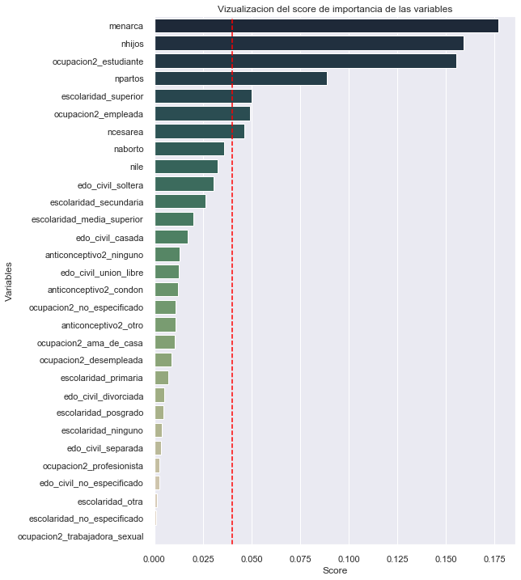

```python
sns.set_style("darkgrid")
pp = sns.cubehelix_palette(30, start=.1, rot=-.75, reverse=True)
fig = plt.figure(figsize=(8, 12))
#Visualizing Important Features
g = sns.barplot(x=feature_imp, y=feature_imp.index, palette=pp)
# Add labels to your graph
g.axes.axvline(x = 0.04, ls='--', color='red')
plt.xlabel('Score')
plt.ylabel('Variables')
plt.title("Vizualizacion del score de importancia de las variables")
plt.show()
```

```python
################################ SELECTION OF VARIABLES FOR MODEL #############################################
x_entrenamiento = x_entrenamiento[['menarca', 'nhijos', 'ocupacion2_estudiante', 'npartos', 'escolaridad_superior', 'ocupacion2_empleada', 'ncesarea']]
```

# 7. Seleccion del Modelo

El ajuste de los parámetros se hizo para tres modelos distintos: Decision Tree, Random Forest y XGBoost.

Para cada conjunto de parámetros, el modelo uso *temporal cross validation* con *10 folds*.

Dado que consideramos que el uso de este modelo podria ser usado para promover politicas publicas de salud, asumimos que los recursos son finitos y por tanto se busca optimizar los mismos reduciendo al maximo los falsos positivos.

## 7.1. Hiperparámetros del modelo (Magic Loop)

Cada modelo se corrio considerando los siguientes rangos para los parámetros:}

[output not shown]

Probando 3 modelos diferentes con distinto hiperparametros, donde seleccionamos el mejor modelo con base en el score F1, que relaciona las metricas *precision* y *recall*.

Lo anterior considerando que el uso de estos resultados podrá usarse para promover alguna politica pública de salud, donde los recursos son finitos e interesa seleccionar con precison a las personas objetivo.

**Los modelos se corrieron en una Mac Pro con 23 MB en memoria y 8 cores.**

A continuación se muestran los resultados de la métrica seleccionada para cada modelo.

Referencia [aqui](https://medium.com/@dcamarena0229/time-series-split-with-scikit-learn-de7ec17d69cd)

```python
########################################## TEMPORAL CROSS VALIDATION #################################################
tscv = TimeSeriesSplit(n_splits=10)
print(tscv)

X = x_entrenamiento
y = y_entrenamiento

cv = [(train_index, test_index)
      for train_index, test_index in tscv.split(X)]
#    print("TRAIN:", train_index, "TEST:", test_index)
#    X_train, X_test = X.iloc[train_index, :], X.iloc[test_index,:]
#    y_train, y_test = y.iloc[train_index], y.iloc[test_index]
```

```
TimeSeriesSplit(max_train_size=None, n_splits=10)
```

```python
############################################### DECISION TREE ########################################################
classifier = tree.DecisionTreeClassifier()

# Hyperparameters
hyper_param_grid1 = {'max_depth': [1,5,10,20,50,100,500,1000],
                     'min_samples_split': [2,5,10,20,50],
                     'criterion':['gini', 'entropy'],
                     'splitter':['random', 'best'],
                     'presort':[False, True]}

# Grid search!
# verbose for debugging, '3' allows for messages
grid_search = GridSearchCV(classifier,
                           hyper_param_grid1,
                           scoring = 'f1',
                           cv = cv,
                           n_jobs = -1,
                           verbose = 3)
grid_search.fit(x_entrenamiento, y_entrenamiento)

# Best params
grid_search.best_params_

# Best score, average of scores in cv sets
print('Valor de la mejor métrica para el modelo de Decision Tree:', grid_search.best_score_ * 100)
```

```
Fitting 10 folds for each of 320 candidates, totalling 3200 fits
```

```
[Parallel(n_jobs=-1)]: Using backend LokyBackend with 8 concurrent workers.
[Parallel(n_jobs=-1)]: Done  16 tasks      | elapsed:    0.2s
[Parallel(n_jobs=-1)]: Done 976 tasks      | elapsed:    6.4s
[Parallel(n_jobs=-1)]: Done 2576 tasks      | elapsed:   16.2s
```

[output not shown]

```
[Parallel(n_jobs=-1)]: Done 3200 out of 3200 | elapsed:   20.6s finished
```

```python
cv_results_arbol = pd.DataFrame(grid_search.cv_results_)
cv_results_arbol.head()
#
cv_results_arbol.to_csv("Output/DecisionTree.csv", index=False)
```

```python
############################################### RANDOM FOREST ########################################################
classifier = RandomForestClassifier()

# Hyperparameters
hyper_param_grid2 = {'n_estimators': [100, 500, 1000, 5000],
                     'max_depth': [5,10,20,50,100],
                     'max_features': ['sqrt','log2'],
                     'min_samples_split': [2,5,10,20,50]}

# Gid search
grid_search = GridSearchCV(classifier,
                           hyper_param_grid2,
                           scoring = 'f1',
                           cv = cv,
                           n_jobs = -1,
                           verbose = 3)
grid_search.fit(x_entrenamiento, y_entrenamiento)

# Best params
grid_search.best_params_

# Best score
print('Valor de la mejor métrica para el modelo de Random Forest:', grid_search.best_score_ * 100)
```

```
Fitting 10 folds for each of 200 candidates, totalling 2000 fits
```

```
[Parallel(n_jobs=-1)]: Using backend LokyBackend with 8 concurrent workers.
[Parallel(n_jobs=-1)]: Done  16 tasks      | elapsed:   10.3s
[Parallel(n_jobs=-1)]: Done 112 tasks      | elapsed:  3.0min
[Parallel(n_jobs=-1)]: Done 272 tasks      | elapsed:  7.9min
[Parallel(n_jobs=-1)]: Done 496 tasks      | elapsed: 15.4min
[Parallel(n_jobs=-1)]: Done 784 tasks      | elapsed: 27.1min
[Parallel(n_jobs=-1)]: Done 1136 tasks      | elapsed: 42.7min
[Parallel(n_jobs=-1)]: Done 1552 tasks      | elapsed: 61.9min
[Parallel(n_jobs=-1)]: Done 2000 out of 2000 | elapsed: 82.8min finished
```

[output not shown]

```python
cv_results_forest = pd.DataFrame(grid_search.cv_results_)
cv_results_forest.head()
#Save to file
cv_results_forest.to_csv("Output/RandomForest.csv", index=False)
```

```python
############################################### XGBOOST ########################################################
classifier = xgb.XGBClassifier()

# Hyperparameters
hyper_param_grid = {'max_depth': [5,10,20,50,100],
                    'min_child_weight': [2,5,10,20,50],
                    'learning_rate':[0.01,0.05,0.1],
                    'objective':['binary:logistic', 'binary:logitraw','binary:hinge']
                    }

# Grid search!
grid_search = GridSearchCV(classifier,
                           hyper_param_grid,
                           scoring = 'f1',
                           cv = cv,
                           n_jobs = -1,
                           verbose = 3)
grid_search.fit(x_entrenamiento, y_entrenamiento)

# Best params
grid_search.best_params_

# Best score
print('Valor de la mejor métrica para el modelo de XGBoost:', grid_search.best_score_ * 100)
```

```
Fitting 10 folds for each of 225 candidates, totalling 2250 fits
```

```
[Parallel(n_jobs=-1)]: Using backend LokyBackend with 8 concurrent workers.
[Parallel(n_jobs=-1)]: Done  16 tasks      | elapsed:    7.3s
[Parallel(n_jobs=-1)]: Done 112 tasks      | elapsed:   33.4s
[Parallel(n_jobs=-1)]: Done 272 tasks      | elapsed:  1.7min
[Parallel(n_jobs=-1)]: Done 496 tasks      | elapsed:  3.7min
[Parallel(n_jobs=-1)]: Done 784 tasks      | elapsed:  6.1min
[Parallel(n_jobs=-1)]: Done 1136 tasks      | elapsed:  8.9min
[Parallel(n_jobs=-1)]: Done 1552 tasks      | elapsed: 12.7min
[Parallel(n_jobs=-1)]: Done 2032 tasks      | elapsed: 17.0min
[Parallel(n_jobs=-1)]: Done 2250 out of 2250 | elapsed: 19.3min finished
```

[output not shown]

```python
cv_results_XGBoost = pd.DataFrame(grid_search.cv_results_)
cv_results_XGBoost.head()
# Save to file
cv_results_XGBoost.to_csv("Output/XGBoost.csv", index=False)
```

## 7.2. Selección del modelo y parámetros

```python
####################################### SELECTION OF MODEL AND HYPERPARAMETERS #######################################
results_all = pd.concat([cv_results_forest, cv_results_arbol, cv_results_XGBoost], axis=0, sort='False').sort_values(by='rank_test_score', ascending=True).head()

results_all.to_csv("Output/all_models.csv", index=False)

# Best parameters according to specifided metric
results_all.iloc[0,:].params
```

```
{'learning_rate': 0.05,
 'max_depth': 10,
 'min_child_weight': 10,
 'objective': 'binary:hinge'}
```

```python
#cv_results_forest
#cv_results_arbol
#cv_results_XGBoost
```

# 8. Predicción en la muestra de prueba

Se hacen todas las transformaciones qe se hicieron en la muestra de entrenamiento a la muestra de prueba.

A continuación se presentas las métricas con la muestra de prueba

```python
################################## PREDICTION FOR 'test' SET ################################################
# Imputation for test set
df = x_prueba

var = 'edo_civil'
aux = df[[var]]
aux_imputed_edo_civil = aux_imputer_edo_civil.transform(aux)
df[var] = aux_imputed_edo_civil

var = 'escolaridad'
aux = df[[var]]
aux_imputed_escolaridad = aux_imputer_escolaridad.transform(aux)
df[var] = aux_imputed_escolaridad

var = 'menarca'
aux = df[[var]]
aux_imputed_menarca = aux_imputer_menarca.transform(aux)
df[var] = aux_imputed_menarca

var = 'anticonceptivo2'
aux = df[[var]]
aux_imputed_anticonceptivo2 = aux_imputer_anticonceptivo2.transform(aux)
df[var]=aux_imputed_anticonceptivo2

var = 'ocupacion2'
aux = df[[var]]
aux_imputed_ocupacion2 = aux_imputer_ocupacion2.transform(aux)
df[var]=aux_imputed_ocupacion2

var = 'nhijos'
aux = df[[var]]
aux_imputed_nhijos = aux_imputer_nhijos.transform(aux)
df[var]=aux_imputed_nhijos

var = 'naborto'
aux = df[[var]]
aux_imputed_naborto = aux_imputer_naborto.transform(aux)
df[var]=aux_imputed_naborto

var = 'npartos'
aux = df[[var]]
aux_imputed_nparto = aux_imputer_nparto.transform(aux)
df[var]=aux_imputed_nparto

var = 'ncesarea'
aux = df[[var]]
aux_imputed_ncesarea = aux_imputer_ncesarea.transform(aux)
df[var]=aux_imputed_ncesarea

var = 'nile'
aux = df[[var]]
aux_imputed_nile = aux_imputer_nile.transform(aux)
df[var]=aux_imputed_nile
```

```python
# One-hot encoder for test set
dummies = feature_selection.transforma_cat_dummies(x_prueba, string_variables, False)
x_prueba = pd.concat([x_prueba, dummies], axis = 1)
x_prueba = x_prueba.drop(string_variables, axis = 1)
```

```python
# Variables for test set
x_prueba = x_prueba[['menarca', 'nhijos', 'ocupacion2_estudiante', 'npartos', 'escolaridad_superior', 'ocupacion2_empleada', 'ncesarea']]
```

```python
#x_prueba
```

```python
################################################# SELECTED MODEL ##############################################

# Specify parameters via map
param_finales = {'learning_rate': 0.05, 'max_depth': 10, 'min_child_weight': 10, 'objective': 'binary:hinge'}

NUM_ROUNDS = 5000

xgdmat = xgb.DMatrix(x_entrenamiento, y_entrenamiento)

best_model = xgb.train(param_finales, xgdmat, NUM_ROUNDS)
```

```python
# we can then plot our feature importances using a built-in method.
# This is similar to the feature importances found in sklearn.
#sns.set_style("darkgrid")
#xgb.plot_importance(best_model)
```

```python
######################################## PREDICTION FOR "test" SET #####################################
testdmat = xgb.DMatrix(x_prueba)
y_predict = best_model.predict(testdmat)
#y_predict
```

[output not shown]

```python
# Change to 0/1 tag, if necessary
# THRESHOLD = 0.5

#y_predict[y_predict > THRESHOLD] = 1
#y_predict[y_predict <= THRESHOLD] = 0
##y_predict
```

[output not shown]

```python
###################################### SELECTED MODEL METRICS ################################################

print('Accuracy:', accuracy_score(y_predict, y_prueba))
```

```
Accuracy: 0.7624771854742275
```

```python
print('Recall:', recall_score(y_prueba, y_predict, average='weighted'))
```

```
Recall: 0.7624771854742275
```

```python
print('F1 score:', f1_score(y_prueba, y_predict, average='weighted'))
```

```
F1 score: 0.7598880976406563
```

```python
# ROC curve
fpr, tpr, thresholds = metrics.roc_curve(y_prueba, y_predict)
roc_auc = auc(fpr, tpr)
```

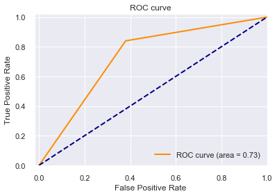

```python
sns.set_style("darkgrid")
plt.figure()
lw = 2
plt.plot(fpr, tpr, color='darkorange', lw=lw, label='ROC curve (area = %0.2f)' % roc_auc)
plt.plot([0, 1], [0, 1], color='navy', lw=lw, linestyle='--')
plt.xlim([-0.02, 1.0])
plt.ylim([0.0, 1.02])
plt.xlabel('False Positive Rate')
plt.ylabel('True Positive Rate')
plt.title('ROC curve')
plt.legend(loc="lower right")
plt.show()
```

```python
# Confusion matrix
conf_mat = pd.DataFrame(confusion_matrix(y_prueba, y_predict))
conf_mat = conf_mat[conf_mat.columns[::-1]].iloc[::-1]
print(conf_mat)
conf_mat.div(conf_mat.sum(0), axis=1).round(2)*100
```

```
      1     0
1  8651  1650
0  2124  3464
```

|  | 1 | 0 |
| --- | --- | --- |
| 1 | 80.0 | 32.0 |
| 0 | 20.0 | 68.0 |

Recordemos que para este proyecto $1$ indica que la edad de la mujer es de 23 años o más, mientras que $0$ indica que la edad es mejor a 23 años. Así, la matriz de confusion indica:

- El modelo clasifica correctamente en el $76\%$ de los casos e incorrectamente en el $24\%$
- Del total de mujeres cuya edad fue clasificada como mayor o igual a 23 años, en el $80\%$ de los casos, fueron en efecto mayores a 23 años (**Verdaderos Positivos**). Mientras que en el restante $20\%$, la predicción fue incorrecta, es decir, las mujeres tenían menos de 23 años pero fueron clasificadas como mayores o iguales a 23 (**Falsos Positivos**)
- Del total de casos clasificados con edades menores a 23 años, el $68\%$ tenían, en efecto, menos de 23 años. (**Verdaderos Negativos**) y el $32\%$ fueron mal clasificados pues eran mayores a 23 años (**Falsos Negativos**)

# 9. Consideraciones éticas

Es necesario considerar los siguientes nuances del modelo, se presentan por etapa: